Tanisha Pardasani, Victoria Banka, Mikayla BergWood, Akash Bejarano

All team members contribute equally in this project.

# Hotel Bookings Analysis

## Introduction

The hotel bookings dataset includes booking information for Resort Hotel and City Hotel. It contains information about demographics, reservations, requests, payment methods and amounts, and duration of stay for each hotel.

The adr variable in the data is the average daily rate which has been computed by dividing total staying transactions by total nights stayed. The market_segment variable describes where the incoming bookings are made from (TA/TO meaning Travel Agency and Tour Operator, Corporate, Direct, etc.)

We are exploring peak times of hotel stays through examining the arrival date variable and using this information to predict future bookings. Additionally, we will be analyzing what influeces the adr in order to determine how to get the best deal at each hotel. We will be also analyze what variables can help hotels predict if someone will cancel their booking reservation. Lastly, we will explore which market segments should hotels spend the most resources on.

## Packages

The dplyr package is being used for data manipulation. Some functions used from the package in this report are mutate(), select(), filter(), and summarize().

The ggplot2 package is being used in this report to create graphics and visualizations of the data.

The lubridate package is being used to convert dates in more easily accessible data types and formats. Some functions used from the package in this report are make_date() and mdy().

```r
library(tidyverse)
library(dplyr)
library(ggplot2)
library(lubridate)
```

## Tidying Data

We tidy the data in order make it easy to use for data analysis, the NA values in certain columns have been removed and the data types for columns containing dates have been changed from character type to date type.

Additionally for the market segments variable we have removed "Undefined" as there was only one booking with an undefined market segment and this does not provide any information to the hotels.

```r
hotel = read_csv("hotel_bookings.csv")
```

```r
months <- c("January", "February", "March", "April", "May", "June", "July", "August", "September",
                  "October", "November", "December")
tidy <- hotel %>%
filter (adr != 0, !is.na (arrival_date_year), !is.na (arrival_date_month), !is.na (arrival_date_day_of_month), market_segment != "Undefined")  %>%

mutate ( arrival_date_month = factor(arrival_date_month,levels=months)) %>%

mutate ( arrival_date = make_date (year = arrival_date_year,
                                  month = arrival_date_month, day = arrival_date_day_of_month)) %>%


mutate ( reservation_status_date = mdy (reservation_status_date))

tidy
```

A spec_tbl_df: 117429 × 33

| hotel <chr> | is_canceled <dbl> | lead_time <dbl> | arrival_date_year <dbl> | arrival_date_month <fct> | arrival_date_week_number <dbl> | arrival_date_day_of_month <dbl> | stays_in_weekend_nights <dbl> | stays_in_week_nights <dbl> | adults <dbl> | ⋯ | agent <chr> | company <chr> | days_in_waiting_list <dbl> | customer_type <chr> | adr <dbl> | required_car_parking_spaces <dbl> | total_of_special_requests <dbl> | reservation_status <chr> | reservation_status_date <date> | arrival_date <date> |
| --- | --- | --- | --- | --- | --- | --- | --- | --- | --- | --- | --- | --- | --- | --- | --- | --- | --- | --- | --- | --- |
| Resort Hotel | 0 | 7 | 2015 | July | 27 | 1 | 0 | 1 | 1 | ⋯ | NULL | NULL | 0 | Transient | 75.00 | 0 | 0 | Check-Out | NA | 2015-07-01 |
| Resort Hotel | 0 | 13 | 2015 | July | 27 | 1 | 0 | 1 | 1 | ⋯ | 304 | NULL | 0 | Transient | 75.00 | 0 | 0 | Check-Out | NA | 2015-07-01 |
| Resort Hotel | 0 | 14 | 2015 | July | 27 | 1 | 0 | 2 | 2 | ⋯ | 240 | NULL | 0 | Transient | 98.00 | 0 | 1 | Check-Out | NA | 2015-07-01 |
| Resort Hotel | 0 | 14 | 2015 | July | 27 | 1 | 0 | 2 | 2 | ⋯ | 240 | NULL | 0 | Transient | 98.00 | 0 | 1 | Check-Out | NA | 2015-07-01 |
| Resort Hotel | 0 | 0 | 2015 | July | 27 | 1 | 0 | 2 | 2 | ⋯ | NULL | NULL | 0 | Transient | 107.00 | 0 | 0 | Check-Out | NA | 2015-07-01 |
| Resort Hotel | 0 | 9 | 2015 | July | 27 | 1 | 0 | 2 | 2 | ⋯ | 303 | NULL | 0 | Transient | 103.00 | 0 | 1 | Check-Out | NA | 2015-07-01 |
| Resort Hotel | 1 | 85 | 2015 | July | 27 | 1 | 0 | 3 | 2 | ⋯ | 240 | NULL | 0 | Transient | 82.00 | 0 | 1 | Canceled | NA | 2015-07-01 |
| Resort Hotel | 1 | 75 | 2015 | July | 27 | 1 | 0 | 3 | 2 | ⋯ | 15 | NULL | 0 | Transient | 105.50 | 0 | 0 | Canceled | NA | 2015-07-01 |
| Resort Hotel | 1 | 23 | 2015 | July | 27 | 1 | 0 | 4 | 2 | ⋯ | 240 | NULL | 0 | Transient | 123.00 | 0 | 0 | Canceled | NA | 2015-07-01 |
| Resort Hotel | 0 | 35 | 2015 | July | 27 | 1 | 0 | 4 | 2 | ⋯ | 240 | NULL | 0 | Transient | 145.00 | 0 | 0 | Check-Out | NA | 2015-07-01 |
| Resort Hotel | 0 | 68 | 2015 | July | 27 | 1 | 0 | 4 | 2 | ⋯ | 240 | NULL | 0 | Transient | 97.00 | 0 | 3 | Check-Out | NA | 2015-07-01 |
| Resort Hotel | 0 | 18 | 2015 | July | 27 | 1 | 0 | 4 | 2 | ⋯ | 241 | NULL | 0 | Transient | 154.77 | 0 | 1 | Check-Out | NA | 2015-07-01 |
| Resort Hotel | 0 | 37 | 2015 | July | 27 | 1 | 0 | 4 | 2 | ⋯ | 241 | NULL | 0 | Transient | 94.71 | 0 | 0 | Check-Out | NA | 2015-07-01 |
| Resort Hotel | 0 | 68 | 2015 | July | 27 | 1 | 0 | 4 | 2 | ⋯ | 240 | NULL | 0 | Transient | 97.00 | 0 | 3 | Check-Out | NA | 2015-07-01 |
| Resort Hotel | 0 | 37 | 2015 | July | 27 | 1 | 0 | 4 | 2 | ⋯ | 8 | NULL | 0 | Contract | 97.50 | 0 | 0 | Check-Out | NA | 2015-07-01 |
| Resort Hotel | 0 | 12 | 2015 | July | 27 | 1 | 0 | 1 | 2 | ⋯ | 240 | NULL | 0 | Transient | 88.20 | 0 | 0 | Check-Out | NA | 2015-07-01 |
| Resort Hotel | 0 | 0 | 2015 | July | 27 | 1 | 0 | 1 | 2 | ⋯ | NULL | 110 | 0 | Transient | 107.42 | 0 | 0 | Check-Out | NA | 2015-07-01 |
| Resort Hotel | 0 | 7 | 2015 | July | 27 | 1 | 0 | 4 | 2 | ⋯ | 250 | NULL | 0 | Transient | 153.00 | 0 | 1 | Check-Out | NA | 2015-07-01 |
| Resort Hotel | 0 | 37 | 2015 | July | 27 | 1 | 1 | 4 | 1 | ⋯ | 241 | NULL | 0 | Transient | 97.29 | 0 | 1 | Check-Out | NA | 2015-07-01 |
| Resort Hotel | 0 | 72 | 2015 | July | 27 | 1 | 2 | 4 | 2 | ⋯ | 250 | NULL | 0 | Transient | 84.67 | 0 | 1 | Check-Out | NA | 2015-07-01 |
| Resort Hotel | 0 | 72 | 2015 | July | 27 | 1 | 2 | 4 | 2 | ⋯ | 250 | NULL | 0 | Transient | 84.67 | 0 | 1 | Check-Out | NA | 2015-07-01 |
| Resort Hotel | 0 | 72 | 2015 | July | 27 | 1 | 2 | 4 | 2 | ⋯ | 250 | NULL | 0 | Transient | 99.67 | 0 | 1 | Check-Out | NA | 2015-07-01 |
| Resort Hotel | 0 | 127 | 2015 | July | 27 | 1 | 2 | 5 | 2 | ⋯ | 115 | NULL | 0 | Contract | 94.95 | 0 | 1 | Check-Out | NA | 2015-07-01 |
| Resort Hotel | 0 | 78 | 2015 | July | 27 | 1 | 2 | 5 | 2 | ⋯ | 5 | NULL | 0 | Transient | 63.60 | 1 | 0 | Check-Out | NA | 2015-07-01 |
| Resort Hotel | 0 | 48 | 2015 | July | 27 | 1 | 2 | 5 | 2 | ⋯ | 8 | NULL | 0 | Contract | 79.50 | 0 | 0 | Check-Out | NA | 2015-07-01 |
| Resort Hotel | 1 | 60 | 2015 | July | 27 | 1 | 2 | 5 | 2 | ⋯ | 240 | NULL | 0 | Transient | 107.00 | 0 | 2 | Canceled | NA | 2015-07-01 |
| Resort Hotel | 0 | 77 | 2015 | July | 27 | 1 | 2 | 5 | 2 | ⋯ | 240 | NULL | 0 | Transient | 94.00 | 0 | 0 | Check-Out | NA | 2015-07-01 |
| Resort Hotel | 0 | 99 | 2015 | July | 27 | 1 | 2 | 5 | 2 | ⋯ | 240 | NULL | 0 | Transient | 87.30 | 1 | 1 | Check-Out | NA | 2015-07-01 |
| Resort Hotel | 0 | 118 | 2015 | July | 27 | 1 | 4 | 10 | 1 | ⋯ | NULL | NULL | 0 | Transient | 62.00 | 0 | 2 | Check-Out | NA | 2015-07-01 |
| Resort Hotel | 0 | 95 | 2015 | July | 27 | 1 | 4 | 11 | 2 | ⋯ | 241 | NULL | 0 | Transient | 63.86 | 0 | 0 | Check-Out | NA | 2015-07-01 |
| ⋮ | ⋮ | ⋮ | ⋮ | ⋮ | ⋮ | ⋮ | ⋮ | ⋮ | ⋮ | ⋱ | ⋮ | ⋮ | ⋮ | ⋮ | ⋮ | ⋮ | ⋮ | ⋮ | ⋮ | ⋮ |
| City Hotel | 0 | 195 | 2017 | August | 35 | 29 | 1 | 5 | 2 | ⋯ | 9 | NULL | 0 | Transient | 117.00 | 0 | 1 | Check-Out | NA | 2017-08-29 |
| City Hotel | 0 | 100 | 2017 | August | 35 | 31 | 1 | 3 | 2 | ⋯ | 16 | NULL | 0 | Transient | 95.85 | 0 | 0 | Check-Out | NA | 2017-08-31 |
| City Hotel | 0 | 198 | 2017 | August | 35 | 29 | 1 | 5 | 2 | ⋯ | 9 | NULL | 0 | Transient | 119.17 | 0 | 2 | Check-Out | NA | 2017-08-29 |
| City Hotel | 0 | 212 | 2017 | August | 35 | 28 | 2 | 5 | 2 | ⋯ | 7 | NULL | 0 | Transient | 92.17 | 0 | 1 | Check-Out | NA | 2017-08-28 |
| City Hotel | 0 | 212 | 2017 | August | 35 | 28 | 2 | 5 | 2 | ⋯ | 7 | NULL | 0 | Transient | 92.17 | 0 | 2 | Check-Out | NA | 2017-08-28 |
| City Hotel | 0 | 54 | 2017 | August | 35 | 27 | 3 | 5 | 1 | ⋯ | 14 | NULL | 0 | Transient | 266.75 | 0 | 1 | Check-Out | NA | 2017-08-27 |
| City Hotel | 0 | 210 | 2017 | August | 35 | 28 | 2 | 5 | 2 | ⋯ | 7 | NULL | 0 | Transient | 85.59 | 0 | 1 | Check-Out | NA | 2017-08-28 |
| City Hotel | 0 | 212 | 2017 | August | 35 | 28 | 2 | 5 | 2 | ⋯ | 7 | NULL | 0 | Transient | 85.59 | 0 | 0 | Check-Out | NA | 2017-08-28 |
| City Hotel | 0 | 261 | 2017 | August | 35 | 30 | 1 | 4 | 2 | ⋯ | 14 | NULL | 0 | Transient | 99.00 | 0 | 0 | Check-Out | NA | 2017-08-30 |
| City Hotel | 0 | 207 | 2017 | August | 34 | 25 | 3 | 7 | 2 | ⋯ | 14 | NULL | 0 | Transient | 96.25 | 0 | 2 | Check-Out | NA | 2017-08-25 |
| City Hotel | 0 | 201 | 2017 | August | 35 | 30 | 1 | 4 | 1 | ⋯ | 9 | NULL | 0 | Transient | 108.00 | 0 | 2 | Check-Out | NA | 2017-08-30 |
| City Hotel | 0 | 175 | 2017 | August | 35 | 31 | 1 | 3 | 2 | ⋯ | 42 | NULL | 0 | Transient | 86.85 | 0 | 2 | Check-Out | NA | 2017-08-31 |
| City Hotel | 0 | 175 | 2017 | August | 35 | 31 | 1 | 3 | 1 | ⋯ | 42 | NULL | 0 | Transient | 82.35 | 0 | 1 | Check-Out | NA | 2017-08-31 |
| City Hotel | 0 | 175 | 2017 | August | 35 | 31 | 1 | 3 | 1 | ⋯ | 42 | NULL | 0 | Transient | 82.35 | 0 | 1 | Check-Out | NA | 2017-08-31 |
| City Hotel | 0 | 201 | 2017 | August | 35 | 29 | 1 | 5 | 2 | ⋯ | 9 | NULL | 0 | Transient | 117.00 | 0 | 2 | Check-Out | NA | 2017-08-29 |
| City Hotel | 0 | 200 | 2017 | August | 35 | 30 | 1 | 4 | 2 | ⋯ | 16 | NULL | 0 | Transient | 85.50 | 0 | 1 | Check-Out | NA | 2017-08-30 |
| City Hotel | 0 | 165 | 2017 | August | 35 | 29 | 1 | 5 | 3 | ⋯ | 9 | NULL | 0 | Transient | 209.25 | 0 | 3 | Check-Out | NA | 2017-08-29 |
| City Hotel | 0 | 185 | 2017 | August | 35 | 30 | 1 | 4 | 2 | ⋯ | 9 | NULL | 0 | Transient | 99.00 | 0 | 1 | Check-Out | NA | 2017-08-30 |
| City Hotel | 0 | 247 | 2017 | August | 35 | 31 | 1 | 3 | 2 | ⋯ | 42 | NULL | 0 | Transient | 86.85 | 0 | 0 | Check-Out | NA | 2017-08-31 |
| City Hotel | 0 | 109 | 2017 | August | 35 | 31 | 1 | 3 | 2 | ⋯ | 9 | NULL | 0 | Transient | 155.00 | 0 | 1 | Check-Out | NA | 2017-08-31 |
| City Hotel | 0 | 44 | 2017 | August | 35 | 31 | 1 | 3 | 2 | ⋯ | 9 | NULL | 0 | Transient | 140.75 | 0 | 1 | Check-Out | NA | 2017-08-31 |
| City Hotel | 0 | 188 | 2017 | August | 35 | 31 | 2 | 3 | 2 | ⋯ | 14 | NULL | 0 | Transient | 99.00 | 0 | 0 | Check-Out | NA | 2017-08-31 |
| City Hotel | 0 | 135 | 2017 | August | 35 | 30 | 2 | 4 | 3 | ⋯ | 7 | NULL | 0 | Transient | 209.00 | 0 | 0 | Check-Out | NA | 2017-08-30 |
| City Hotel | 0 | 164 | 2017 | August | 35 | 31 | 2 | 4 | 2 | ⋯ | 42 | NULL | 0 | Transient | 87.60 | 0 | 0 | Check-Out | NA | 2017-08-31 |
| City Hotel | 0 | 21 | 2017 | August | 35 | 30 | 2 | 5 | 2 | ⋯ | 394 | NULL | 0 | Transient | 96.14 | 0 | 2 | Check-Out | NA | 2017-08-30 |
| City Hotel | 0 | 23 | 2017 | August | 35 | 30 | 2 | 5 | 2 | ⋯ | 394 | NULL | 0 | Transient | 96.14 | 0 | 0 | Check-Out | NA | 2017-08-30 |
| City Hotel | 0 | 102 | 2017 | August | 35 | 31 | 2 | 5 | 3 | ⋯ | 9 | NULL | 0 | Transient | 225.43 | 0 | 2 | Check-Out | NA | 2017-08-31 |
| City Hotel | 0 | 34 | 2017 | August | 35 | 31 | 2 | 5 | 2 | ⋯ | 9 | NULL | 0 | Transient | 157.71 | 0 | 4 | Check-Out | NA | 2017-08-31 |
| City Hotel | 0 | 109 | 2017 | August | 35 | 31 | 2 | 5 | 2 | ⋯ | 89 | NULL | 0 | Transient | 104.40 | 0 | 0 | Check-Out | NA | 2017-08-31 |
| City Hotel | 0 | 205 | 2017 | August | 35 | 29 | 2 | 7 | 2 | ⋯ | 9 | NULL | 0 | Transient | 151.20 | 0 | 2 | Check-Out | NA | 2017-08-29 |

## Question Number 1:

When are peak times for hotel bookings and how are other variables affected during these times? Determining peak times can help hotels determine prices according to the demand during certain times.

To answer this question, a new table will be formulated and will include the average daily rate as well as how much in advance people book their room. These will be grouped by the arrival month.

```r
peak_month_times <-
tidy %>%

group_by (arrival_date_month = as.numeric (arrival_date_month)) %>%
summarize ( count = n(), mean_lead_time = mean(lead_time), mean_avg_daily_rate = mean(adr)) %>%


arrange(desc(count))

peak_month_times
```

A tibble: 12 × 4

| arrival_date_month <dbl> | count <int> | mean_lead_time <dbl> | mean_avg_daily_rate <dbl> |
| --- | --- | --- | --- |
| 8 | 13709 | 122.22533 | 141.82636 |
| 7 | 12491 | 137.24289 | 128.51357 |
| 5 | 11611 | 118.79537 | 110.38057 |
| 4 | 10953 | 95.50872 | 101.62719 |
| 10 | 10929 | 124.32556 | 89.76696 |
| 6 | 10819 | 129.14780 | 117.96627 |
| 9 | 10351 | 137.53309 | 106.64301 |
| 3 | 9642 | 70.87586 | 81.95151 |
| 2 | 7921 | 48.48870 | 74.94783 |
| 11 | 6641 | 77.86252 | 75.49510 |
| 12 | 6561 | 75.20287 | 83.78304 |
| 1 | 5801 | 46.08757 | 71.91377 |

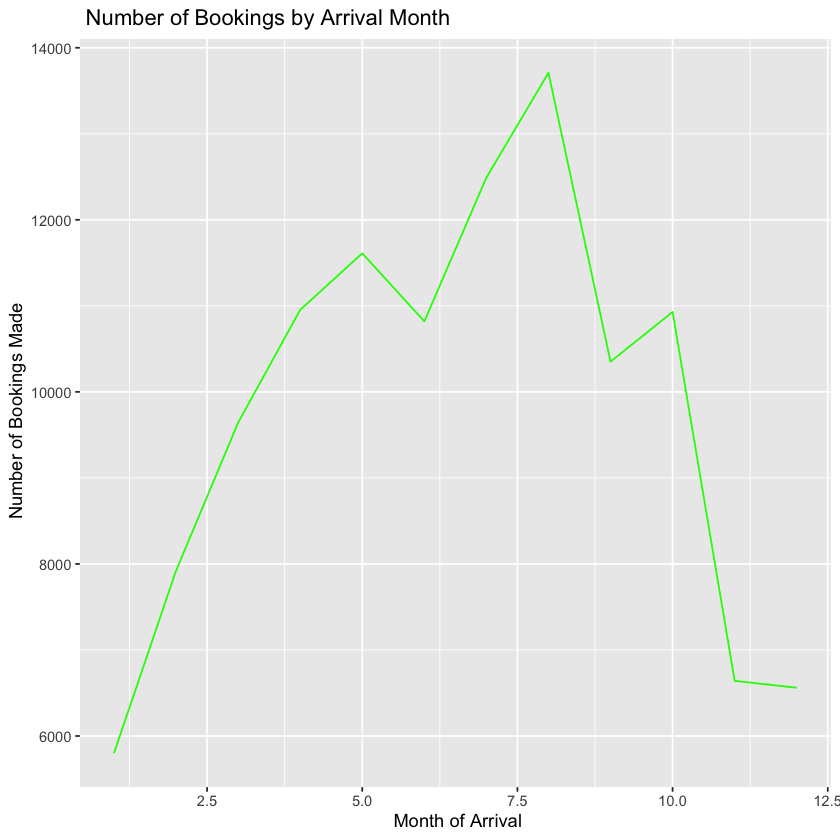

```r
ggplot (peak_month_times) +
    geom_line(mapping = aes(x=arrival_date_month, y=count), color="green") +
    ggtitle( " Number of Bookings by Arrival Month") +
    xlab (" Month of Arrival") +
    ylab (" Number of Bookings Made")
```

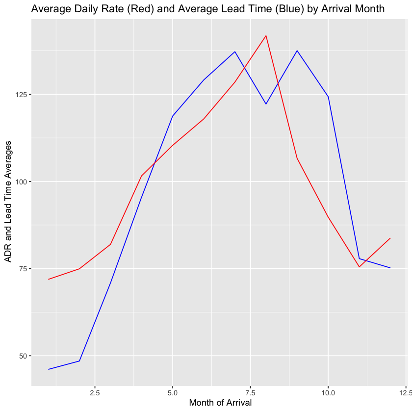

```r
ggplot (peak_month_times) +
    geom_line(mapping = aes(x=arrival_date_month, y=mean_lead_time), color="blue") +
    geom_line(mapping = aes(x=arrival_date_month, y=mean_avg_daily_rate), color="red")  +
    ggtitle( "Average Daily Rate (Red) and Average Lead Time (Blue) by Arrival Month") +
    xlab (" Month of Arrival") +
    ylab (" ADR and Lead Time Averages")
```

Conclusion : By looking at the newly formulated tables, we see that the most booking are made for August, July, and May. These are Summer/Spring months, so it makes sense that most people travel during this time. We can also see that the average lead time and average daily rates for these month tend to be higher than non-peak months. This suggests that people book more in advance during peak times and prices are higher - probably because there is so much demand during this time.

```r
linreg <- lm(tidy$adr ~ as.factor(tidy$arrival_date_month))

summary(linreg)
```

```
Call:
lm(formula = tidy$adr ~ as.factor(tidy$arrival_date_month))

Residuals:
   Min     1Q Median     3Q    Max
-140.3  -27.1   -3.9   19.6 5318.0

Coefficients:
                                            Estimate Std. Error t value
(Intercept)                                  71.9138     0.5770 124.630
as.factor(tidy$arrival_date_month)February    3.0341     0.7595   3.995
as.factor(tidy$arrival_date_month)March      10.0377     0.7303  13.746
as.factor(tidy$arrival_date_month)April      29.7134     0.7136  41.636
as.factor(tidy$arrival_date_month)May        38.4668     0.7066  54.438
as.factor(tidy$arrival_date_month)June       46.0525     0.7152  64.393
as.factor(tidy$arrival_date_month)July       56.5998     0.6983  81.057
as.factor(tidy$arrival_date_month)August     69.9126     0.6884 101.564
as.factor(tidy$arrival_date_month)September  34.7292     0.7208  48.182
as.factor(tidy$arrival_date_month)October    17.8532     0.7139  25.007
as.factor(tidy$arrival_date_month)November    3.5813     0.7898   4.534
as.factor(tidy$arrival_date_month)December   11.8693     0.7920  14.986
                                            Pr(>|t|)
(Intercept)                                  < 2e-16 ***
as.factor(tidy$arrival_date_month)February  6.47e-05 ***
as.factor(tidy$arrival_date_month)March      < 2e-16 ***
as.factor(tidy$arrival_date_month)April      < 2e-16 ***
as.factor(tidy$arrival_date_month)May        < 2e-16 ***
as.factor(tidy$arrival_date_month)June       < 2e-16 ***
as.factor(tidy$arrival_date_month)July       < 2e-16 ***
as.factor(tidy$arrival_date_month)August     < 2e-16 ***
as.factor(tidy$arrival_date_month)September  < 2e-16 ***
as.factor(tidy$arrival_date_month)October    < 2e-16 ***
as.factor(tidy$arrival_date_month)November  5.78e-06 ***
as.factor(tidy$arrival_date_month)December   < 2e-16 ***
---
Signif. codes:  0 ‘***’ 0.001 ‘**’ 0.01 ‘*’ 0.05 ‘.’ 0.1 ‘ ’ 1

Residual standard error: 43.95 on 117417 degrees of freedom
Multiple R-squared:  0.2021,	Adjusted R-squared:  0.202
F-statistic:  2704 on 11 and 117417 DF,  p-value: < 2.2e-16
```

Based on the linear regression we can see that the most expensive months to book a hotel are June, July, and August. June is estimated to have an average daily rate of 117.96. July is estimated to have an average daily rate of 128.51. August is estimated to have an average daily rate of 141.81. The cheapest month on average is January with an estimated average daily rate of 71.91.

## Question Number 2 :

We would like to examine the influence that different variables have on the average daily rate, in order to determine how to get the best deal at each hotel. In the last question, we determined that during peak times the average daily rate is higher, and now we would like to determine what effect the room type and lead time have on the price.

```r
tidy_resort <- tidy %>% filter(hotel=="Resort Hotel")
tidy_city <- tidy %>% filter(hotel=="City Hotel")
```

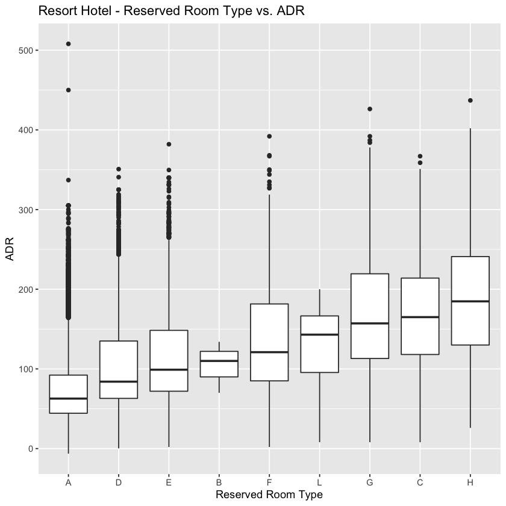

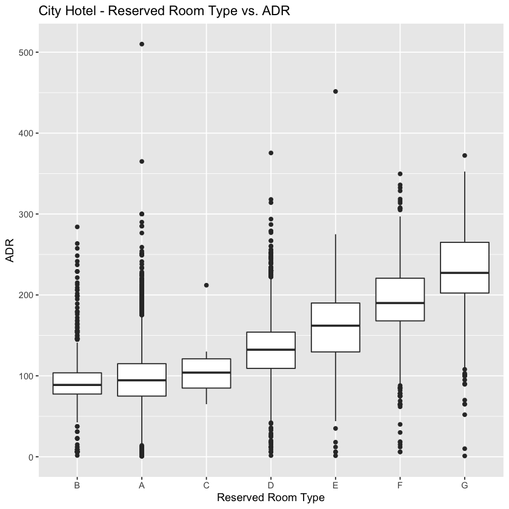

```r
tidy_resort %>% group_by(reserved_room_type) %>% mutate(median=median(adr)) %>% ggplot() + geom_boxplot(mapping=aes(x=reorder(reserved_room_type,median),y=adr)) + xlab("Reserved Room Type") + ylab("ADR") + ggtitle("Resort Hotel - Reserved Room Type vs. ADR")
tidy_city %>% filter(adr<4000) %>% group_by(reserved_room_type) %>% mutate(median=median(adr)) %>% ggplot() + geom_boxplot(mapping=aes(x=reorder(reserved_room_type,median),y=adr)) + xlab("Reserved Room Type") + ylab("ADR") +ggtitle("City Hotel - Reserved Room Type vs. ADR")
```

Since the rooms are divided into different categories based on type, it is safe to assume that they may differ in price. By creating a boxplot for each individual hotel, we are able to see not only which rooms are more expensive, but also that the ranking of prices for each room type differs between the two hotels. By restricting adr values for the city hotel to less than 4000, we are able to get rid of the one extreme value that is most likely an error, and make the scale of each plot equal so the price comparisons are very easy to visualize. By organizing the plots by median average daily rates, it is easy to see which rooms are the best deal for each hotel. Although the city hotel has more expensive rooms on average, it has a better deal for some of the room types. For example, if a family was interested in renting a C type room, they would likely find a better deal for it at the city hotel.

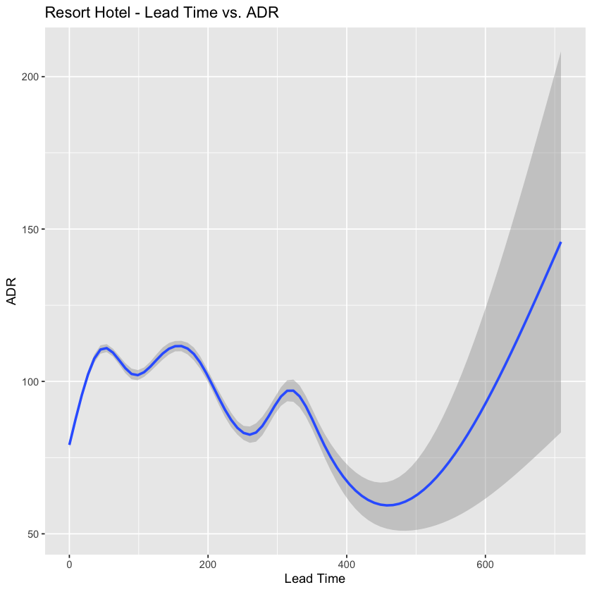

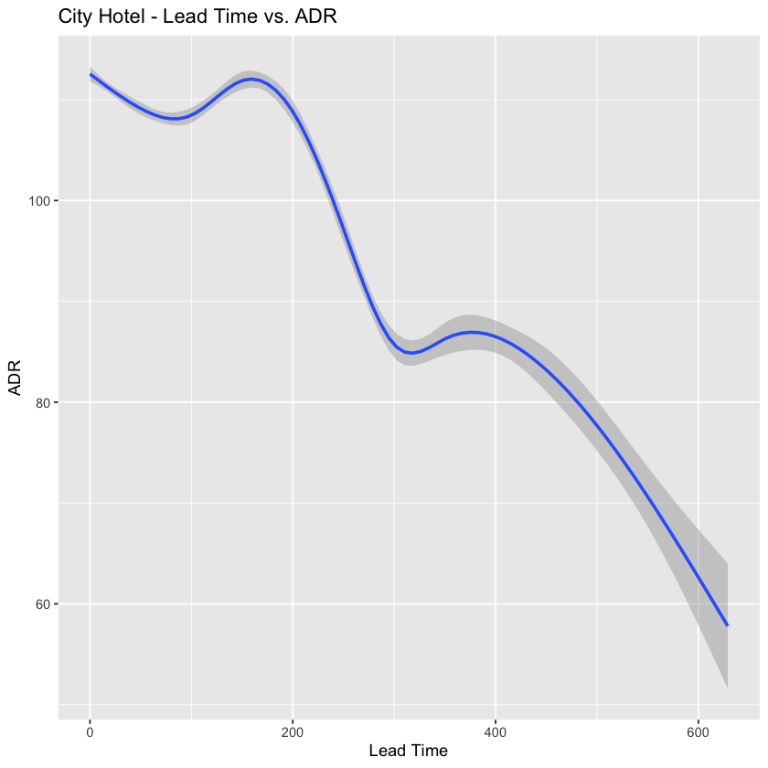

```r
tidy_resort %>% ggplot() +geom_smooth(mapping=aes(x=lead_time,y=adr)) + xlab("Lead Time") + ylab("ADR") + ggtitle("Resort Hotel - Lead Time vs. ADR")

tidy_city  %>% ggplot() +geom_smooth(mapping=aes(x=lead_time,y=adr)) + xlab("Lead Time") + ylab("ADR") +ggtitle("City Hotel - Lead Time vs. ADR")
```

By plotting lead time with adr for each hotel, we are able to see how effective booking ahead of time is for getting a lower rate. We can see that prices at the City Hotel are more consistent, but that typically, the farther one books in advance, the lower rate they will get. Prices for Resort hotel fluctuate over a wider range, and one is not necessarily guaranteed a lower rate for booking earlier. In fact, after 600 days, there is a sharp increase in prices, and before 50 days, the price is much lower. This may be because the hotel is trying to fill its empty rooms at the last minute. Therefore, if a customer is planning ahead for a trip, they will likely recieve a better deal staying at the City Hotel, but if it is a last minute trip, the Resort Hotel would be a safer bet.

By plotting the ADR against both the room type and lead time, we see that they are closely related, so customers are able to get a much lower rate if they account for these different factors, and choose the hotel that best suits their needs for the cheapest price.

## Question Number 3 :

What variables can help hotels predict if someone will cancel their booking reservation?

Cancellations can cause some problems for hotels when scheduling staff etc. It may be useful to have some red flags for hotels to watch out for so cancellations don't sneak up on them and they may be able to base overbooking on these red flags.

To answer this question, is_cancel will be compared to the variables prev_cancellations, lead_time and market_segment. This will be done by finding the proportion of cancellations per value of the independent variable for prev_cancellations and lead_time. For market_segment, the proportion of cancellations per each type of market segment must be found. These results will then be displayed visually using techniques we have learned in class.

Investigate if number of previous cancellations increases the likelihood that someone will cancel their reservation by finding the proportion of cancellations based on the value of previous cancellations. Then use geom_point and geom_smooth in a faceted ggplot by the hotel variable to visualize the results.

```r
prev_cancel_table <- tidy %>%
select(hotel, is_canceled, previous_cancellations) %>%
group_by(hotel, previous_cancellations, is_canceled) %>%
summarize(num_cancel = n()) %>%
spread(key = is_canceled, value = num_cancel) %>%
mutate(not_canceled = `0`, canceled = `1`) %>%
select(hotel, previous_cancellations, not_canceled, canceled) %>%
mutate(not_canceled = ifelse(is.na(not_canceled) == TRUE, 0, not_canceled)) %>%
mutate(canceled = ifelse(is.na(canceled) == TRUE, 0, canceled)) %>%
mutate(prop_canceled = canceled / (not_canceled + canceled)) %>%
mutate(prop_not_canceled = not_canceled / (not_canceled + canceled))
prev_cancel_table
```

A grouped_df: 21 × 6

| hotel <chr> | previous_cancellations <dbl> | not_canceled <dbl> | canceled <int> | prop_canceled <dbl> | prop_not_canceled <dbl> |
| --- | --- | --- | --- | --- | --- |
| City Hotel | 0 | 44832 | 27985 | 0.38431960 | 0.61568040 |
| City Hotel | 1 | 177 | 4938 | 0.96539589 | 0.03460411 |
| City Hotel | 2 | 42 | 11 | 0.20754717 | 0.79245283 |
| City Hotel | 3 | 38 | 6 | 0.13636364 | 0.86363636 |
| City Hotel | 4 | 9 | 1 | 0.10000000 | 0.90000000 |
| City Hotel | 5 | 10 | 1 | 0.09090909 | 0.90909091 |
| City Hotel | 6 | 15 | 7 | 0.31818182 | 0.68181818 |
| City Hotel | 11 | 25 | 10 | 0.28571429 | 0.71428571 |
| City Hotel | 13 | 1 | 11 | 0.91666667 | 0.08333333 |
| City Hotel | 21 | 0 | 1 | 1.00000000 | 0.00000000 |
| Resort Hotel | 0 | 28103 | 10117 | 0.26470434 | 0.73529566 |
| Resort Hotel | 1 | 143 | 747 | 0.83932584 | 0.16067416 |
| Resort Hotel | 2 | 19 | 25 | 0.56818182 | 0.43181818 |
| Resort Hotel | 3 | 1 | 13 | 0.92857143 | 0.07142857 |
| Resort Hotel | 4 | 3 | 3 | 0.50000000 | 0.50000000 |
| Resort Hotel | 5 | 2 | 1 | 0.33333333 | 0.66666667 |
| Resort Hotel | 14 | 0 | 14 | 1.00000000 | 0.00000000 |
| Resort Hotel | 19 | 0 | 19 | 1.00000000 | 0.00000000 |
| Resort Hotel | 24 | 0 | 48 | 1.00000000 | 0.00000000 |
| Resort Hotel | 25 | 0 | 25 | 1.00000000 | 0.00000000 |
| Resort Hotel | 26 | 0 | 26 | 1.00000000 | 0.00000000 |

First I select my necessary variables which are; hotel, is_canceled, previous_cancellations. I then group by all of those variables in order to creat a new variable "num_cancel" to count the number of canceled bookings and not canceled bookings for each hotel and for each value of previous cancellations. I then spread by is canceled in order to have a column of the canceled booking values and the not canceled booking values. Then in order to make the table more readable I renamed the is_canceled values. Because the value in spread would return NA instead of 0 if there were no canceled or not canceled bookings for a given previous_cancellation value, I changed these NAs to 0. I then found the proportion of canceled and not canceled bookings.

Below I have graphed the results using geom_point(), geom_smooth(), and facet_wrap() in order to compare the two types of hotels. I graphed both the proportion of canceled bookings and the propotion of bookings not canceled. Even though the graphs are inverses of each other I though it may be useful to see both.

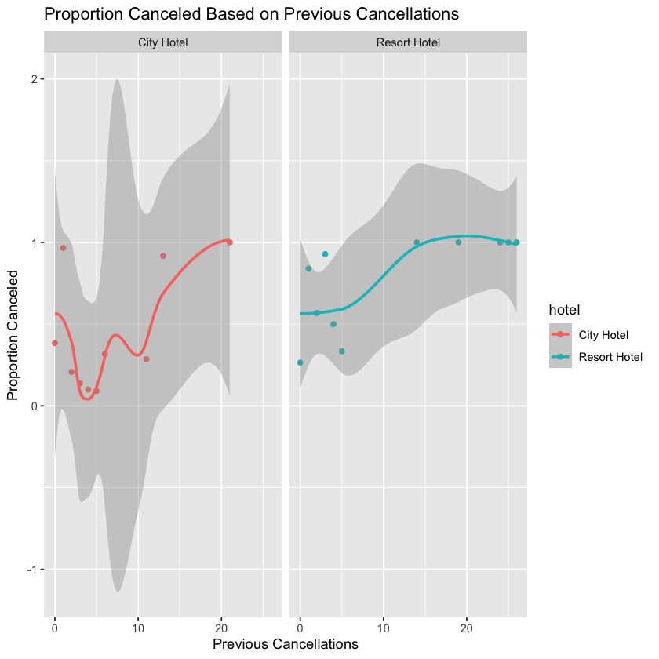

```r
ggplot(data = prev_cancel_table, mapping = aes(x = previous_cancellations, y = prop_canceled, color = hotel)) +
geom_point() +
geom_smooth() +
facet_wrap(~ hotel) +
ggtitle("Proportion Canceled Based on Previous Cancellations") +
xlab("Previous Cancellations") +
ylab("Proportion Canceled")
```

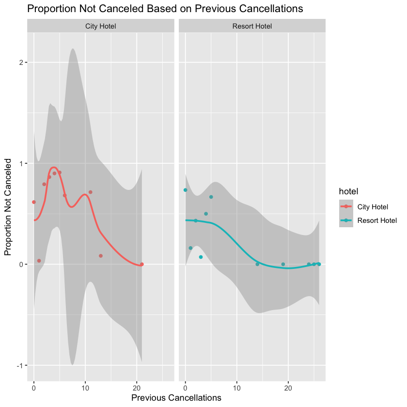

```r
ggplot(data = prev_cancel_table, mapping = aes(x = previous_cancellations, y = prop_not_canceled, color = hotel)) +
geom_point() +
geom_smooth() +
facet_wrap(~ hotel) +
ggtitle("Proportion Not Canceled Based on Previous Cancellations") +
xlab("Previous Cancellations") +
ylab("Proportion Not Canceled")
```

Based on these graphs we can infer that given the data, the chances that someone will cancel their reservation goes up as the number of previous cancellations goes up and the chances someone will NOT cancel their reservation goes down as the number of previous cancellations goes up. This appears to be generally true for both hotels however, the data is more consistent for the Resort Hotel.

Is there an association between how far in advance someone books their reservation and the likelihood they will end up canceling? Use geom_smooth and facet by hotel again, after finding the proportion of cancellations for every lead_time.

```r
lead_book_table2 <- tidy %>%
select(hotel, is_canceled, lead_time) %>%
group_by(hotel, lead_time, is_canceled) %>%
summarize(num_cancel = n()) %>%
spread(key = is_canceled, value = num_cancel) %>%
mutate(not_canceled = `0`, canceled = `1`) %>%
select(hotel, lead_time, not_canceled, canceled) %>%
mutate(not_canceled = ifelse(is.na(not_canceled) == TRUE, 0, not_canceled)) %>%
mutate(canceled = ifelse(is.na(canceled) == TRUE, 0, canceled)) %>%
mutate(prop_canceled = canceled / (not_canceled + canceled)) %>%
mutate(prop_not_canceled = not_canceled / (not_canceled + canceled))
head(lead_book_table2)
tail(lead_book_table2)
```

A grouped_df: 6 × 6

| hotel <chr> | lead_time <dbl> | not_canceled <dbl> | canceled <dbl> | prop_canceled <dbl> | prop_not_canceled <dbl> |
| --- | --- | --- | --- | --- | --- |
| City Hotel | 0 | 2443 | 240 | 0.08945211 | 0.9105479 |
| City Hotel | 1 | 1539 | 215 | 0.12257697 | 0.8774230 |
| City Hotel | 2 | 955 | 121 | 0.11245353 | 0.8875465 |
| City Hotel | 3 | 859 | 114 | 0.11716341 | 0.8828366 |
| City Hotel | 4 | 884 | 122 | 0.12127237 | 0.8787276 |
| City Hotel | 5 | 773 | 154 | 0.16612729 | 0.8338727 |

A grouped_df: 6 × 6

| hotel <chr> | lead_time <dbl> | not_canceled <dbl> | canceled <dbl> | prop_canceled <dbl> | prop_not_canceled <dbl> |
| --- | --- | --- | --- | --- | --- |
| Resort Hotel | 462 | 0 | 20 | 1.0000000 | 0.0000000 |
| Resort Hotel | 468 | 17 | 28 | 0.6222222 | 0.3777778 |
| Resort Hotel | 471 | 0 | 6 | 1.0000000 | 0.0000000 |
| Resort Hotel | 532 | 1 | 0 | 0.0000000 | 1.0000000 |
| Resort Hotel | 542 | 22 | 0 | 0.0000000 | 1.0000000 |
| Resort Hotel | 709 | 1 | 0 | 0.0000000 | 1.0000000 |

This process was very similar to that of the first comparison to previous_cancellations. First I select my necessary variables which are; hotel, is_canceled, and lead_time. I then group by all of those variables in order to creat a new variable "num_cancel" to count the number of canceled bookings and not canceled bookings for each hotel and for each value of lead time. I then spread by is_canceled in order to have a column of the canceled booking values and the not canceled booking values. Then in order to make the table more readable I renamed the is_canceled values. Because the value in spread would return NA instead of 0 if there were no canceled or not canceled bookings for a given previous_cancellation value, I changed these NAs to 0. I then found the proportion of canceled and not canceled bookings.

Below I have graphed the results using only geom_smooth() because it looked too messy with geom_point() too. I again use facet_wrap() in order to compare the two types of hotels. I again graphed both the proportion of canceled bookings and the propotion of bookings not canceled. Even though the graphs are inverses of each other I though it may be useful to see both.

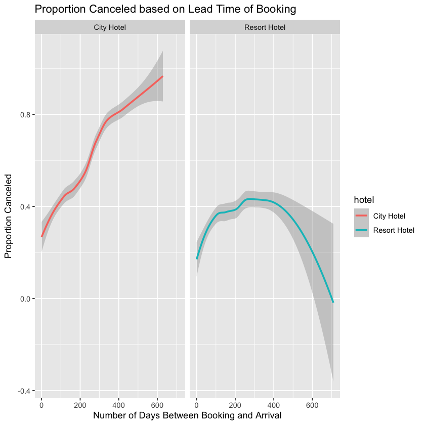

```r
ggplot(data = lead_book_table2, mapping = aes(x = lead_time, y = prop_canceled, color = hotel)) +
geom_smooth() +
facet_wrap(~ hotel) +
ggtitle("Proportion Canceled based on Lead Time of Booking") +
xlab("Number of Days Between Booking and Arrival") +
ylab("Proportion Canceled")
```

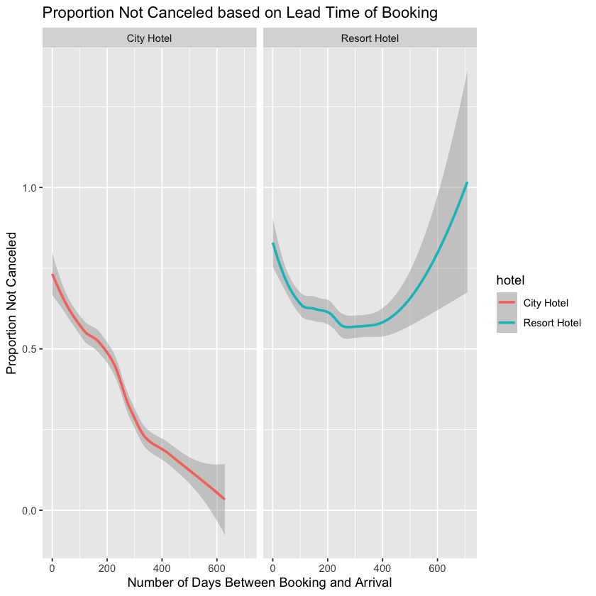

```r
ggplot(data = lead_book_table2, mapping = aes(x = lead_time, y = prop_not_canceled, color = hotel)) +
geom_smooth() +
facet_wrap(~ hotel) +
ggtitle("Proportion Not Canceled based on Lead Time of Booking") +
xlab("Number of Days Between Booking and Arrival") +
ylab("Proportion Not Canceled")
```

Based on these graphs we can infer that given the data, for the City Hotel the proportion of cancellations increase the farther in advance the booking is made and the proportion of bookings not canceled decreases the farther in advance the booking is made. The Resort Hotel on the other hand is a bit more complicated. The proportion of cancellations for the Resort Hotel increase from about 0 days in advance to 300 days in advance and then decrease from 300 days in advance to 700 days in advance.

Because of this inconsistency I decided to investigate the average lead time grouped by each hotel and whether or not it was canceled. The values in this table shows me that while the Resort Hotel graph is less linear the averages are still relatively similar to the City Hotel. For both hotels the average lead time for bookings that end up being canceled is larger than the average lead time of bookings that are not canceled.

```r
avg_table <- tidy %>%
select(hotel, is_canceled, lead_time) %>%
group_by(is_canceled, hotel) %>%
summarize(avg_lead_time = mean(lead_time))
avg_table
```

A grouped_df: 4 × 3

| is_canceled <dbl> | hotel <chr> | avg_lead_time <dbl> |
| --- | --- | --- |
| 0 | City Hotel | 81.92948 |
| 0 | Resort Hotel | 79.61257 |
| 1 | City Hotel | 150.69218 |
| 1 | Resort Hotel | 128.82886 |

See if each type of market segment designation is more associated with cancellation or less associated with cancellation than the others. Find the proportion of cancellations for each method of market segment, then use geom_bar and facet_wrap by hotel to visualize the results.

```r
markseg_table <- tidy %>%
select(hotel, is_canceled, market_segment) %>%
group_by(hotel, is_canceled, market_segment) %>%
summarize(num_cancel = n()) %>%
spread(key = is_canceled, value = num_cancel) %>%
mutate(not_canceled = `0`, canceled = `1`) %>%
select(hotel, market_segment, not_canceled, canceled) %>%
mutate(not_canceled = ifelse(is.na(not_canceled) == TRUE, 0, not_canceled)) %>%
mutate(canceled = ifelse(is.na(canceled) == TRUE, 0, canceled)) %>%
mutate(prop_canceled = canceled / (not_canceled + canceled)) %>%
mutate(prop_not_canceled = not_canceled / (not_canceled + canceled)) %>%
print()
```

```
# A tibble: 13 x 6
# Groups:   hotel [2]
   hotel     market_segment not_canceled canceled prop_canceled prop_not_cancel…
   <chr>     <chr>                 <int>    <int>         <dbl>            <dbl>
 1 City Hot… Aviation                180       51        0.221             0.779
 2 City Hot… Complementary            31        3        0.0882            0.912
 3 City Hot… Corporate              2318      638        0.216             0.784
 4 City Hot… Direct                 4935     1047        0.175             0.825
 5 City Hot… Groups                 4222     9609        0.695             0.305
 6 City Hot… Offline TA/TO          9365     7146        0.433             0.567
 7 City Hot… Online TA             24098    14477        0.375             0.625
 8 Resort H… Complementary            27        2        0.0690            0.931
 9 Resort H… Corporate              1908      349        0.155             0.845
10 Resort H… Direct                 5528      856        0.134             0.866
11 Resort H… Groups                 3264     2464        0.430             0.570
12 Resort H… Offline TA/TO          6251     1125        0.153             0.847
13 Resort H… Online TA             11293     6242        0.356             0.644
```

This code is also pretty similar to the other two subparts. First I select my necessary variables which are; hotel, is_canceled, and market_segment. I then group by all of those variables in order to creat a new variable "num_cancel" to count the number of canceled bookings and not canceled bookings for each hotel and for each type of market segment. I then spread by is canceled in order to have a column of the canceled booking values and the not canceled booking values. Then in order to make the table more readable I renamed the is_canceled values. Because the value in spread would return NA instead of 0 if there were no canceled or not canceled bookings for a given previous_cancellation value, I changed these NAs to 0. I then found the proportion of canceled and not canceled bookings.

Below I have graphed the results using geom_col() where each bar represents a type of market segment, and facet_wrap() in order to compare the two types of hotels. I then flipped the coordinates so that the market segments were easier to read.

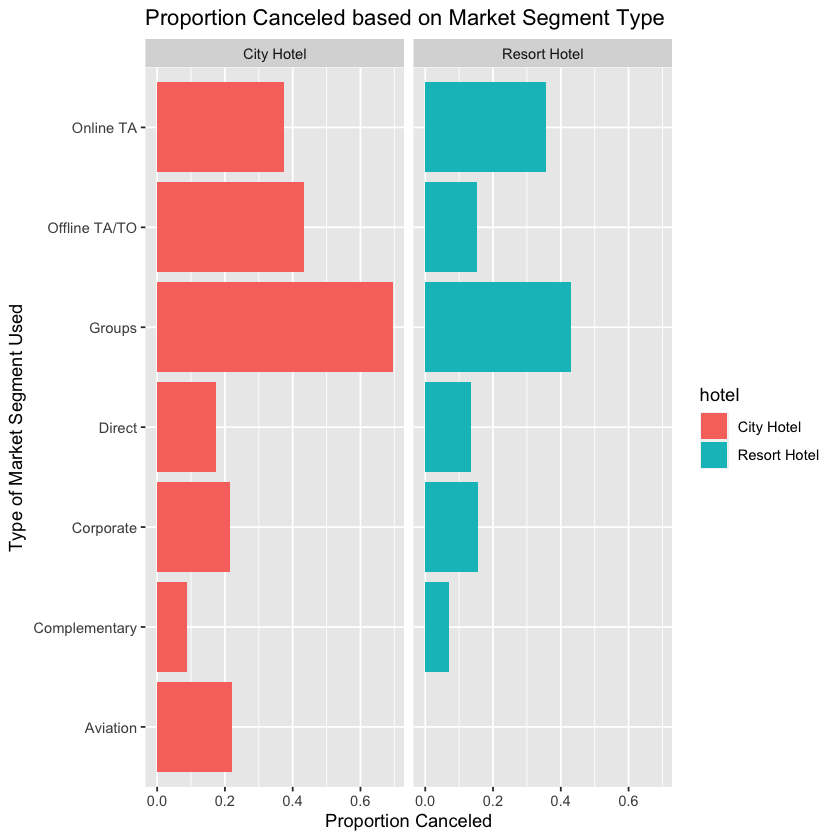

```r
ggplot(data = markseg_table) +
geom_col(mapping = aes(x = market_segment, y = prop_canceled, fill = hotel)) +
facet_wrap(~ hotel) +
coord_flip() +
ggtitle("Proportion Canceled based on Market Segment Type") +
xlab("Type of Market Segment Used") +
ylab("Proportion Canceled")
```

The highest proportion for both hotels is in the "Groups" market segment. So people that make their bookings under market segment "Groups" are the most likely to cancel their hotel booking.

## Question 4

Market segments (the channels in which the hotels get their bookings) play a huge impact in how hotels perform. By advertizing their hotel through the differing market segments, hotels are able to reach different audiences and determing which market segment to adverize the most can help hotels earn more revenue and by extension more profit.

Thus we will explore which Market Segment should hotels spend the most resources on?

One way to decide which market segment to spend more resources on is by determining which market segment brings in the most bookings to the hotels; specifically what proportion of the bookings made to the hotels are done by each market segments.

A grouped_df: 13 × 4

| hotel <chr> | market_segment <chr> | Bookings <int> | Booking_Percentage <dbl> |
| --- | --- | --- | --- |
| City Hotel | Aviation | 231 | 0.29569892 |
| City Hotel | Complementary | 34 | 0.04352279 |
| City Hotel | Corporate | 2956 | 3.78392217 |
| City Hotel | Direct | 5982 | 7.65745008 |
| City Hotel | Groups | 13831 | 17.70481311 |
| City Hotel | Offline TA/TO | 16511 | 21.13543267 |
| City Hotel | Online TA | 38575 | 49.37916027 |
| Resort Hotel | Complementary | 29 | 0.07377445 |
| Resort Hotel | Corporate | 2257 | 5.74168765 |
| Resort Hotel | Direct | 6384 | 16.24055560 |
| Resort Hotel | Groups | 5728 | 14.57172658 |
| Resort Hotel | Offline TA/TO | 7376 | 18.76415070 |
| Resort Hotel | Online TA | 17535 | 44.60810501 |

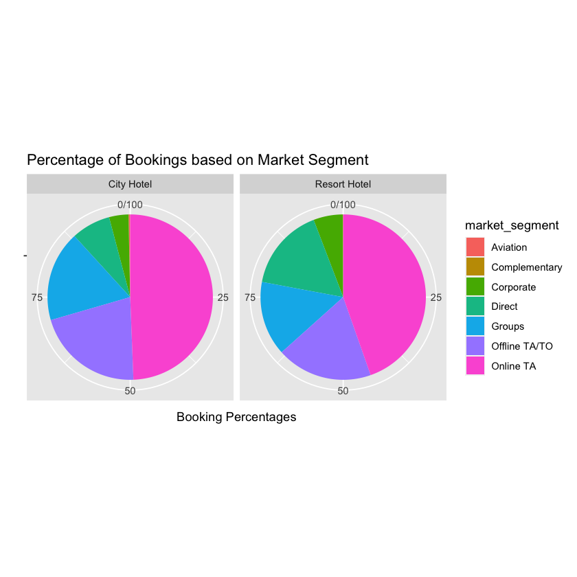

```r
city <- tidy %>% filter(hotel == "City Hotel")
resort <- tidy %>% filter(hotel == "Resort Hotel")

totalBookingCity <- nrow(city)
totalBookingResort <- nrow(resort)

Market <- tidy %>% group_by(hotel, market_segment) %>% summarize(Bookings = n())
Market <- Market %>% mutate(Booking_Percentage = ifelse(hotel == "City Hotel", 100*(Bookings/totalBookingCity), 100*(Bookings/totalBookingResort)))

Market
ggplot(data = Market) +
geom_bar(mapping = aes(x ="", y = Booking_Percentage, fill = market_segment), stat="identity") +
facet_wrap(~hotel)+
coord_polar(theta ="y")+
ggtitle("Percentage of Bookings based on Market Segment")+
ylab("Booking Percentages")+
xlab(" ")
```

While spending more resources on TA/TO's and letting them advertize on your behalf to consumers can be less work for the hotels, an approach where the hotels spend more resources on market segments that bring in the most bookings may not always be the correct decision.

Hotels should also think about the average money each market segment brings to the hotel per booking and see if they should instead allocate more resources to the market segments that bring in the most money on average per booking.

In order to investigate this, we need to know how much money on average is each market segment bringing into the hotel per booking. First we need to get a subset of the tidied data where we only have the bookings that were not cancelled as these are the bookings that bring in money. From there, we estimate the revenue that the hotels get by multiplying the adr (average daily rate) by the duration of the booking (duration of booking is estimated by adding the number of nights during the week and weekend of the booking). Additionally, in order to determine the correct approach it is necessary to not only look at the revenue brought in by each market segment in general but also look at the trend per year that each market segment brings in.

This is done by first grouping the data by market segment, year, and hotel and then using functions such as spread(), separate(), unite() to create a table that portrays the average revenue brought to each hotel per market segment per year. Then ggplot, geom_line, and facet ggplot are used to visualize this information.

A grouped_df: 7 × 7

| market_segment <chr> | City_2015 <dbl> | City_2016 <dbl> | City_2017 <dbl> | Resort_2015 <dbl> | Resort_2016 <dbl> | Resort_2017 <dbl> |
| --- | --- | --- | --- | --- | --- | --- |
| Aviation | 0.0000 | 418.28125 | 365.63524 | 0.0000 | 0.00000 | 0.0000 |
| Complementary | 175.2500 | 78.91667 | 49.33333 | 35.2000 | 57.53846 | 127.2811 |
| Corporate | 156.3275 | 161.67724 | 149.31969 | 166.5705 | 78.15964 | 110.7191 |
| Direct | 291.1944 | 320.86013 | 369.58983 | 508.3384 | 370.93374 | 496.9288 |
| Groups | 227.6966 | 217.81272 | 249.03676 | 255.3460 | 247.40339 | 326.6848 |
| Offline TA/TO | 235.1313 | 269.24311 | 320.11656 | 500.1680 | 448.09711 | 585.7457 |
| Online TA | 312.7231 | 345.49677 | 400.07154 | 452.8500 | 392.29302 | 490.9187 |

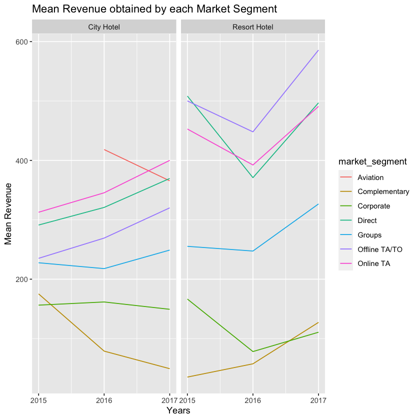

```r
revenueTable <- tidy %>% filter(is_canceled == 0) %>%
mutate(duration = stays_in_weekend_nights + stays_in_week_nights) %>%
mutate(revenue = duration * adr)

table1 <- revenueTable %>% group_by(market_segment, hotel, arrival_date_year) %>% summarize(meanRevenue = mean(revenue, na.rm= TRUE)) %>% arrange(desc(meanRevenue))
ggplot(data = table1) + geom_line(mapping = aes(x = arrival_date_year, y = meanRevenue, color = market_segment)) +
facet_wrap(~hotel)+
ggtitle("Mean Revenue obtained by each Market Segment")+
xlab("Years")+
ylab("Mean Revenue")+
scale_x_continuous(breaks = c(2015,2016,2017))

table2 <- table1 %>% spread(key = arrival_date_year, value = meanRevenue, fill =0) %>% group_by(hotel, market_segment)
table2 <- table2 %>% unite(col = "years", "2015":"2017") %>%
spread(key = hotel, value = years) %>%
separate("City Hotel", into = paste0(c("City_2015","City_2016","City_2017")), sep="_", convert=TRUE) %>%
separate("Resort Hotel", into = paste0(c("Resort_2015", "Resort_2016", "Resort_2017")), sep="_", convert=TRUE)
table2 <- table2 %>% mutate( Resort_2015 = ifelse(is.na(Resort_2015), 0,Resort_2015), Resort_2016 = ifelse(is.na(Resort_2016), 0,Resort_2016), Resort_2017 = ifelse(is.na(Resort_2017), 0,Resort_2017))
table2
```

Thus City Hotel should allocate a large portion of their resources to Online TA, Direct followed by Offline TA/TO, Groups, etc. While Resort Hotel should allocate a large portion of their resources to Offline TA/TO, followed by Direct, Online TA, etc.

However this approach of spending the most resources on the market segments that bring in the most money on average per booking is not the ideal approach either.

By allocating more of their resources towards Online TA, Direct, Offline TA/TO, hotels will intern be able to get more bookings towards these market segements and thus earn even more revenue and by extension more profit.